# Factorised GLMM model for Psychotic Risk prediction from SUbstance Use and other factors in CATSS

Silpa Soni Nallacheruvu

2026-04-16

## Load the simulated Data

```r
catss <- read_csv("catss_final_data.csv")
```

## Check complete cases

```r
print(paste("Number of complete cases:", sum(complete.cases(catss))))
```

```
## [1] "Number of complete cases: 4033"
```

## Create the CCA dataset

```r
catss <- catss[complete.cases(catss), ]
```

## Split the data into training and testing dataset

Based on their twin_id

```r
test_size <- 0.25

# Get unique IDs
unique_ids <- unique(catss$cmpair)

# Sample test IDs
n_test <- floor(length(unique_ids) * test_size)
test_ids <- sample(unique_ids, size = n_test)

# Split dataset
test_df <- catss[catss$cmpair %in% test_ids, ]
train_df <- catss[!catss$cmpair %in% test_ids, ]

# Print summary
cat(sprintf(
  "Train: %d rows (%d IDs), Test: %d rows (%d IDs)\n",
  nrow(train_df), length(unique(train_df$cmpair)),
  nrow(test_df), length(unique(test_df$cmpair))
))
```

```
## Train: 3011 rows (2018 IDs), Test: 1022 rows (672 IDs)
```

## Prepare the data for the model formula by creating interaction terms and factor variables

```r
# get a list of columns with their prefix
SUD15_vars <- grep("^SUD15", names(catss), value = TRUE)
SCZ15_vars <- grep("^SCZ15", names(catss), value = TRUE)
PRS_vars <- grep("^PRS", names(catss), value = TRUE)
ADHD9_vars <- grep("^ADHD9", names(catss), value = TRUE)
ASD9_vars <- grep("^ASD9", names(catss), value = TRUE)
ACE_vars <- grep("^ACE", names(catss), value = TRUE)
SES_vars <- grep("^SES", names(catss), value = TRUE)
PCA_vars <- grep("^PC", names(catss), value = TRUE)[1:2]
Sex_var <- grep("^SEX", names(catss), value = TRUE)
Batch_var <- grep("^batch", names(catss), value = TRUE)[1]

factor_terms <- paste(
  c(
    paste0("factor(", SUD15_vars, ")")
  ),
  collapse = " + "
)


covariate_terms <- paste(
  c(SCZ15_vars, ADHD9_vars, ASD9_vars, ACE_vars, SES_vars, PRS_vars, Sex_var),
  collapse = " + "
)

# PCA terms according to the genetic batch
genetic_confounding_terms <- paste(
  c(
    paste0("factor(", Batch_var, ") : ", PCA_vars)
  ),
  collapse = " + "
)

# create interaction terms between SUD15 variables and all other covariates
factor_interaction_terms <- paste(
  c(
    paste0("factor(", SUD15_vars, "):(", SCZ15_vars, ")"),
    paste0("factor(", SUD15_vars, "):(", ADHD9_vars, ")"),
    paste0("factor(", SUD15_vars, "):(", ASD9_vars, ")"),
    paste0("factor(", SUD15_vars, "):(", ACE_vars, ")"),
    paste0("factor(", SUD15_vars, "):(", SES_vars, ")"),
    paste0("factor(", SUD15_vars, "):(", PRS_vars, ")"),
    paste0("factor(", SUD15_vars, "):(", Sex_var, ")")
  ),
  collapse = " + "
)

interaction_terms <- paste(
  c(
    paste0(SUD15_vars ,":", SCZ15_vars),
    paste0(SUD15_vars, ":", ADHD9_vars),
    paste0(SUD15_vars, ":", ASD9_vars),
    paste0(SUD15_vars, ":", ACE_vars),
    paste0(SUD15_vars, ":", SES_vars),
    paste0(SUD15_vars, ":", PRS_vars),
    paste0(SUD15_vars, ":", Sex_var)
  ),
  collapse = " + "
)

train_df$cmpair <- as.factor(train_df$cmpair)
```

# Fit a GLMM Model

## Fit a Positive GLMM Model

```r
pos_glmm_formula_str <- paste(
  "SCZ18_Pos_Norm ~",
  factor_terms,  "+",
  covariate_terms, "+",
  factor_interaction_terms, "+",
  genetic_confounding_terms,  "+",
  "(1 | cmpair)"
)

pos_glmm_formula <- as.formula(pos_glmm_formula_str)

pos_glmm_model <- glmer(
  pos_glmm_formula,
  data = train_df
)
```

```
## fixed-effect model matrix is rank deficient so dropping 57 columns / coefficients
```

```r
summary(pos_glmm_model)
```

```
## Linear mixed model fit by REML ['lmerMod']
## Formula: SCZ18_Pos_Norm ~ factor(SUD15_Cigarettes15) + factor(SUD15_Snuff15) +
##     factor(SUD15_Alcohol15) + factor(SUD15_Cannabis15) + factor(SUD15_Painkillers_opioids15) +
##     factor(SUD15_OtherDrugs15) + SCZ15_Spied15 + SCZ15_Others_Read_thoughts15 +
##     SCZ15_Special_messages15 + SCZ15_Special_powers15 + SCZ15_Under_control_special_power15 +
##     SCZ15_Read_others_minds15 + SCZ15_Seen_hallucinations15 +
##     SCZ15_Extreme_excitement15 + SCZ15_Irritable15 + SCZ15_Unrealistic_abilities15 +
##     SCZ15_Not_tired15 + SCZ15_Too_much_energy15 + SCZ15_Racing_thoughts15 +
##     SCZ15_Talking_fast15 + SCZ15_Sexual_inappropriate15 + SCZ15_Rage_attacks15 +
##     SCZ15_Hear_voices15 + SCZ15_headaches15 + SCZ15_worry15 +
##     SCZ15_unhappy15 + SCZ15_lose_confidence15 + SCZ15_easily_scared15 +
##     SCZ15_PROD_seen_hallucinations9 + ADHD9_fail_close_attention9 +
##     ADHD9_difficulty_with_attention9 + ADHD9_not_listening9 +
##     ADHD9_difficulty_following_instructions9 + ADHD9_difficulty_organizing_tasks9 +
##     ADHD9_avoid_mental_effort_tasks9 + ADHD9_often_lose_things9 +
##     ADHD9_easily_distracted9 + ADHD9_often_forgetful9 + ADHD9_difficulty_hold_still9 +
##     ADHD9_often_move9 + ADHD9_often_run9 + ADHD9_difficulty_calm9 +
##     ADHD9_often_motor9 + ADHD9_talk_excess9 + ADHD9_often_blurt_out9 +
##     ADHD9_difficulty_waiting9 + ADHD9_often_interrupt9 + ADHD9_easily_bored9 +
##     ASD9_delay_language9 + ASD9_difficulty_converse9 + ASD9_repeat_words9 +
##     ASD9_difficulty_pretend_play9 + ASD9_talk_too_high_low9 +
##     ASD9_difficulty_on_track9 + ASD9_difficulty_express9 + ASD9_difficulty_socialize9 +
##     ASD9_uninterested_sharing9 + ASD9_own_terms9 + ASD9_difficulty_expect_behavior9 +
##     ASD9_easily_influenced9 + ASD9_absorbed_own9 + ASD9_absorbed_problems9 +
##     ASD9_strange_movements9 + ASD9_absorbed_details9 + ASD9_dislike_change9 +
##     ACE15_bullied_often15 + ACE15_tease_bullying15 + ACE15_emotional_bullying15 +
##     ACE15_rumours_bullying15 + ACE15_bullying_by_num15 + ACE15_bullying_time15 +
##     ACE18_emotional_abuse18 + ACE18_witness_crime18 + ACE18_hate_crime18 +
##     ACE15_other_bullying15 + ACE18_other_abuse18 + SES_birth_country_mother +
##     SES_education_mother + SES_birth_country_father + SES_education_father +
##     PRS_Amygdala_excitatory + PRS_Cerebellar_inhibitory + PRS_CGE_interneuron +
##     PRS_Deep_layer_corticothalamic + PRS_Deep_layer_intratelencepha +
##     PRS_Eccentric_medium_spiny_neu + PRS_Hippocampal_CA1_3 +
##     PRS_Hippocampal_CA4 + PRS_Hippocampal_dentate_gyrus + PRS_LAMP5_LHX6_and_Chandelier +
##     PRS_Medium_spiny_neuron + PRS_MGE_interneuron + PRS_Miscellaneous +
##     PRS_Thalamic_excitatory + PRS_Upper_layer_intratelenceph +
##     PRS_all + SEX + factor(SUD15_Cigarettes15):(SCZ15_Spied15) +
##     factor(SUD15_Snuff15):(SCZ15_Others_Read_thoughts15) + factor(SUD15_Alcohol15):(SCZ15_Special_messages15) +
##     factor(SUD15_Cannabis15):(SCZ15_Special_powers15) + factor(SUD15_Painkillers_opioids15):(SCZ15_Under_control_special_power15) +
##     factor(SUD15_OtherDrugs15):(SCZ15_Read_others_minds15) +
```

[output cut: 1341 more lines]

```
## factor(SUD15_Alcohol15)4:SEX                                               0.974
## factor(SUD15_Cannabis15)1:SEX                                              0.839
## factor(SUD15_Cannabis15)2:SEX                                              0.686
## factor(SUD15_Painkillers_opioids15)1:SEX                                   0.185
## factor(SUD15_Painkillers_opioids15)2:SEX                                   0.240
## factor(SUD15_Painkillers_opioids15)3:SEX                                   0.038
## factor(SUD15_OtherDrugs15)1:SEX                                           -0.553
## factor(SUD15_OtherDrugs15)2:SEX                                            0.228
## factor(SUD15_OtherDrugs15)3:SEX                                            0.602
## factor(batch)GSA1:PC1                                                     -0.157
## factor(batch)GSA3:PC1                                                      0.043
## factor(batch)PSYC:PC1                                                     -0.022
## factor(batch)GSA1:PC2                                                     -0.312
## factor(batch)GSA3:PC2                                                     -0.178
## factor(batch)PSYC:PC2                                                     -1.301
```

```
##
## Correlation matrix not shown by default, as p = 427 > 12.
## Use print(x, correlation=TRUE)  or
##     vcov(x)        if you need it
```

```
## fit warnings:
## fixed-effect model matrix is rank deficient so dropping 57 columns / coefficients
```

### Compute p-values

```r
pos_glmm_coefs <- summary(pos_glmm_model)$coefficients

pos_df_resid <- df.residual(pos_glmm_model)

pos_glmm_p_values <- 2 * (1 - pt(abs(pos_glmm_coefs[, "t value"]), df = pos_df_resid))

pos_glmm_coefs <- cbind(pos_glmm_coefs, p_value = pos_glmm_p_values)

pos_glmm_coefs <- as.data.frame(pos_glmm_coefs)

pos_glmm_coefs$significance <- cut(
  pos_glmm_coefs$p_value,
  breaks = c(-Inf, 0.001, 0.01, 0.05, 0.1, Inf),
  labels = c("***", "**", "*", ".", "")
)

# Prepare clean table
pos_coefs_table <- pos_glmm_coefs %>%
  mutate(Variable = rownames(.)) %>%
  filter(p_value < 0.05, Variable != "(Intercept)") %>%
  arrange(p_value) %>%
  select(Estimate, `Std. Error`, p_value, significance) %>%
  mutate(
    Estimate = round(Estimate, 3),
    `Std. Error` = round(`Std. Error`, 3),
    p_value = signif(p_value, 3)
  )

kable(pos_coefs_table, format = "html") %>%
  kable_styling(bootstrap_options = c("striped", "hover", "condensed"))
```

Estimate

Std. Error

p_value

significance

ACE18_emotional_abuse18

-0.039

0.004

0.00e+00

***

SCZ15_Extreme_excitement15

0.010

0.002

5.00e-07

***

SCZ15_Seen_hallucinations15

0.020

0.005

1.98e-05

***

ACE18_witness_crime18

-0.024

0.007

3.64e-04

***

SCZ15_Too_much_energy15

0.009

0.003

4.36e-04

***

SCZ15_Read_others_minds15

0.008

0.003

2.67e-03

SES_birth_country_father

-0.034

0.012

4.40e-03

SCZ15_headaches15

0.008

0.003

5.04e-03

factor(SUD15_Cigarettes15)2:ADHD9_easily_bored9

0.294

0.107

5.91e-03

SCZ15_Rage_attacks15

0.011

0.004

6.43e-03

factor(SUD15_OtherDrugs15)1:ADHD9_often_run9

-0.079

0.031

1.02e-02

factor(SUD15_Alcohol15)3:SES_birth_country_father

0.043

0.017

1.08e-02

SCZ15_Talking_fast15

0.007

0.003

1.22e-02

factor(SUD15_Cigarettes15)2:SEX

-0.194

0.079

1.35e-02

factor(SUD15_Alcohol15)2:ADHD9_not_listening9

-0.058

0.024

1.63e-02

ACE15_emotional_bullying15

0.032

0.014

1.76e-02

factor(SUD15_OtherDrugs15)2

-0.645

0.278

2.06e-02

SCZ15_Spied15

0.007

0.003

2.06e-02

ADHD9_often_interrupt9

-0.013

0.006

2.57e-02

factor(SUD15_Alcohol15)4:ADHD9_not_listening9

-0.036

0.016

2.85e-02

factor(SUD15_OtherDrugs15)2:SES_education_mother

0.176

0.083

3.36e-02

factor(SUD15_Snuff15)2:SCZ15_Extreme_excitement15

-0.211

0.101

3.72e-02

factor(SUD15_OtherDrugs15)2:ASD9_difficulty_on_track9

0.413

0.200

3.89e-02

factor(SUD15_Cigarettes15)3:ASD9_delay_language9

0.079

0.039

4.17e-02

factor(SUD15_Alcohol15)4:SCZ15_lose_confidence15

0.019

0.009

4.31e-02

factor(SUD15_OtherDrugs15)3:SCZ15_headaches15

0.167

0.084

4.71e-02

ASD9_easily_influenced9

0.008

0.004

4.88e-02

factor(SUD15_Alcohol15)2:SES_birth_country_father

0.033

0.017

4.93e-02

factor(SUD15_Painkillers_opioids15)3:ASD9_dislike_change9

-0.088

0.045

4.98e-02

### Check the twin random effect

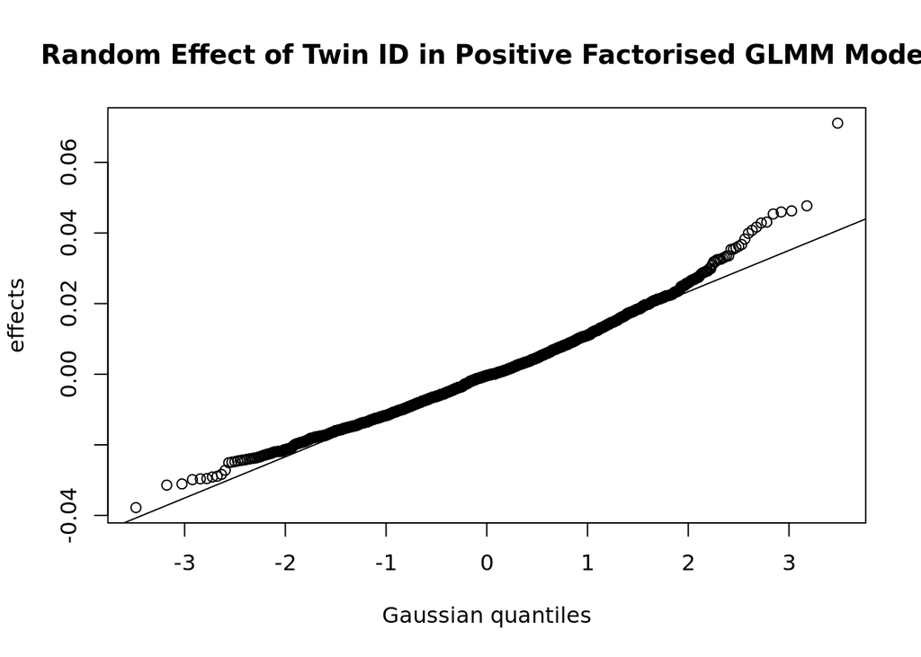

```r
pos_re <- ranef(pos_glmm_model)$cmpair[,1]
pos_qq <- qqnorm(pos_re, plot.it = FALSE)

plot(pos_qq$x, pos_qq$y,
     xlab = "Gaussian quantiles",
     ylab = "effects",
     main = "Random Effect of Twin ID in Positive Factorised GLMM Model")
abline(lm(pos_qq$y ~ pos_qq$x), col = "black")
```

### Evaluate the model predictions

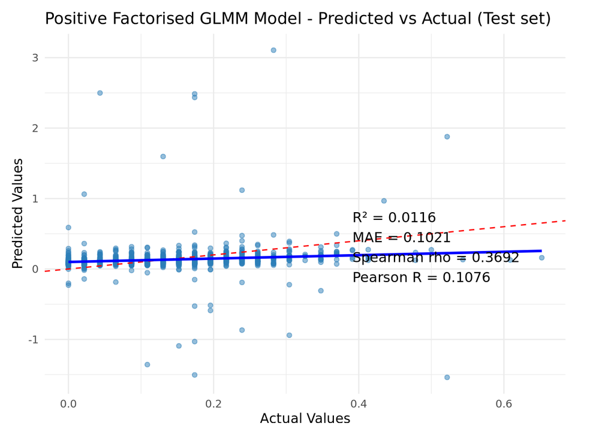

```r
pos_glmm_y_pred <- predict(pos_glmm_model, newdata = test_df, allow.new.levels = TRUE, type = "response")
pos_y_true <- test_df$SCZ18_Pos_Norm


# Create dataframe
pos_glmm_df <- data.frame(
  actual = pos_y_true,
  predicted = pos_glmm_y_pred
)

# Residuals
pos_glmm_df$residuals <- pos_glmm_df$actual - pos_glmm_df$predicted

# Metrics
r2 <- cor(pos_glmm_df$actual, pos_glmm_df$predicted)^2
mae <- mean(abs(pos_glmm_df$actual - pos_glmm_df$predicted))
pearson_r <- cor(pos_glmm_df$actual, pos_glmm_df$predicted)
spearman_r <- cor(pos_glmm_df$actual, pos_glmm_df$predicted, method = "spearman")

metrics_text <- sprintf(
  "R² = %.4f\nMAE = %.4f\nSpearman rho = %.4f\nPearson R = %.4f",
  r2, mae, spearman_r, pearson_r
)

# predicted vs actual plot
p1 <- ggplot(pos_glmm_df, aes(x = actual, y = predicted)) +
  geom_point(alpha = 0.5, color = "#2C7FB8") +
  geom_abline(intercept = 0, slope = 1, linetype = "dashed", color = "red") +
  geom_smooth(method = "lm", se = FALSE, color = "blue") +

  annotate("text",
           x = max(pos_glmm_df$actual) * 0.6,
           y = max(pos_glmm_df$predicted) * 0.1,   # move inside plot
           label = metrics_text,
           hjust = 0,
           size = 4) +

  coord_cartesian(clip = "off") +  # prevents clipping

  labs(
    title = "Positive Factorised GLMM Model - Predicted vs Actual (Test set)",
    x = "Actual Values",
    y = "Predicted Values"
  ) +
  theme_minimal() +
  theme(plot.margin = margin(10, 40, 10, 10))  # extra space

p1
```

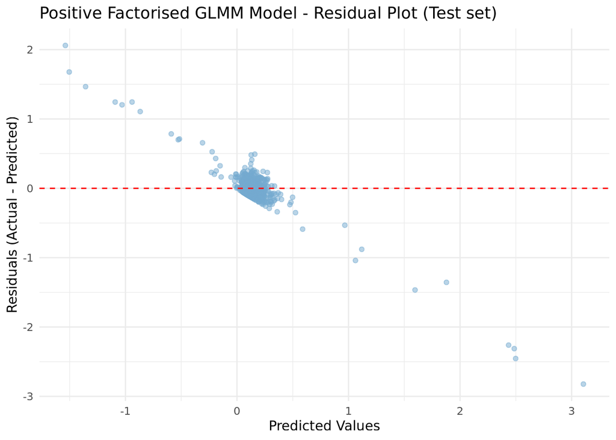

```r
# residual plot
p2 <- ggplot(pos_glmm_df, aes(x = predicted, y = residuals)) +
  geom_point(alpha = 0.5, color = "#74A9CF") +
  geom_hline(yintercept = 0, linetype = "dashed", color = "red") +

  labs(
    title = "Positive Factorised GLMM Model - Residual Plot (Test set)",
    x = "Predicted Values",
    y = "Residuals (Actual - Predicted)"
  ) +
  theme_minimal()

p2
```

## Fit a Negative GLMM Model

```r
neg_glmm_formula_str <- paste(
  "SCZ18_Neg_Norm ~",
  factor_terms,  "+",
  covariate_terms, "+",
  factor_interaction_terms, "+",
  genetic_confounding_terms,  "+",
  "(1 | cmpair)"
)

neg_glmm_formula <- as.formula(neg_glmm_formula_str)

neg_glmm_model <- glmer(
  neg_glmm_formula,
  data = train_df
)
```

```
## fixed-effect model matrix is rank deficient so dropping 57 columns / coefficients
```

```r
summary(neg_glmm_model)
```

```
## Linear mixed model fit by REML ['lmerMod']
## Formula: SCZ18_Neg_Norm ~ factor(SUD15_Cigarettes15) + factor(SUD15_Snuff15) +
##     factor(SUD15_Alcohol15) + factor(SUD15_Cannabis15) + factor(SUD15_Painkillers_opioids15) +
##     factor(SUD15_OtherDrugs15) + SCZ15_Spied15 + SCZ15_Others_Read_thoughts15 +
##     SCZ15_Special_messages15 + SCZ15_Special_powers15 + SCZ15_Under_control_special_power15 +
##     SCZ15_Read_others_minds15 + SCZ15_Seen_hallucinations15 +
##     SCZ15_Extreme_excitement15 + SCZ15_Irritable15 + SCZ15_Unrealistic_abilities15 +
##     SCZ15_Not_tired15 + SCZ15_Too_much_energy15 + SCZ15_Racing_thoughts15 +
##     SCZ15_Talking_fast15 + SCZ15_Sexual_inappropriate15 + SCZ15_Rage_attacks15 +
##     SCZ15_Hear_voices15 + SCZ15_headaches15 + SCZ15_worry15 +
##     SCZ15_unhappy15 + SCZ15_lose_confidence15 + SCZ15_easily_scared15 +
##     SCZ15_PROD_seen_hallucinations9 + ADHD9_fail_close_attention9 +
##     ADHD9_difficulty_with_attention9 + ADHD9_not_listening9 +
##     ADHD9_difficulty_following_instructions9 + ADHD9_difficulty_organizing_tasks9 +
##     ADHD9_avoid_mental_effort_tasks9 + ADHD9_often_lose_things9 +
##     ADHD9_easily_distracted9 + ADHD9_often_forgetful9 + ADHD9_difficulty_hold_still9 +
##     ADHD9_often_move9 + ADHD9_often_run9 + ADHD9_difficulty_calm9 +
##     ADHD9_often_motor9 + ADHD9_talk_excess9 + ADHD9_often_blurt_out9 +
##     ADHD9_difficulty_waiting9 + ADHD9_often_interrupt9 + ADHD9_easily_bored9 +
##     ASD9_delay_language9 + ASD9_difficulty_converse9 + ASD9_repeat_words9 +
##     ASD9_difficulty_pretend_play9 + ASD9_talk_too_high_low9 +
##     ASD9_difficulty_on_track9 + ASD9_difficulty_express9 + ASD9_difficulty_socialize9 +
##     ASD9_uninterested_sharing9 + ASD9_own_terms9 + ASD9_difficulty_expect_behavior9 +
##     ASD9_easily_influenced9 + ASD9_absorbed_own9 + ASD9_absorbed_problems9 +
##     ASD9_strange_movements9 + ASD9_absorbed_details9 + ASD9_dislike_change9 +
##     ACE15_bullied_often15 + ACE15_tease_bullying15 + ACE15_emotional_bullying15 +
##     ACE15_rumours_bullying15 + ACE15_bullying_by_num15 + ACE15_bullying_time15 +
##     ACE18_emotional_abuse18 + ACE18_witness_crime18 + ACE18_hate_crime18 +
##     ACE15_other_bullying15 + ACE18_other_abuse18 + SES_birth_country_mother +
##     SES_education_mother + SES_birth_country_father + SES_education_father +
##     PRS_Amygdala_excitatory + PRS_Cerebellar_inhibitory + PRS_CGE_interneuron +
##     PRS_Deep_layer_corticothalamic + PRS_Deep_layer_intratelencepha +
##     PRS_Eccentric_medium_spiny_neu + PRS_Hippocampal_CA1_3 +
##     PRS_Hippocampal_CA4 + PRS_Hippocampal_dentate_gyrus + PRS_LAMP5_LHX6_and_Chandelier +
##     PRS_Medium_spiny_neuron + PRS_MGE_interneuron + PRS_Miscellaneous +
##     PRS_Thalamic_excitatory + PRS_Upper_layer_intratelenceph +
##     PRS_all + SEX + factor(SUD15_Cigarettes15):(SCZ15_Spied15) +
##     factor(SUD15_Snuff15):(SCZ15_Others_Read_thoughts15) + factor(SUD15_Alcohol15):(SCZ15_Special_messages15) +
##     factor(SUD15_Cannabis15):(SCZ15_Special_powers15) + factor(SUD15_Painkillers_opioids15):(SCZ15_Under_control_special_power15) +
##     factor(SUD15_OtherDrugs15):(SCZ15_Read_others_minds15) +
```

[output cut: 1341 more lines]

```
## factor(SUD15_Alcohol15)4:SEX                                              -1.169
## factor(SUD15_Cannabis15)1:SEX                                              0.797
## factor(SUD15_Cannabis15)2:SEX                                              1.025
## factor(SUD15_Painkillers_opioids15)1:SEX                                   0.736
## factor(SUD15_Painkillers_opioids15)2:SEX                                   2.983
## factor(SUD15_Painkillers_opioids15)3:SEX                                  -0.053
## factor(SUD15_OtherDrugs15)1:SEX                                           -0.919
## factor(SUD15_OtherDrugs15)2:SEX                                           -2.007
## factor(SUD15_OtherDrugs15)3:SEX                                           -0.327
## factor(batch)GSA1:PC1                                                      2.237
## factor(batch)GSA3:PC1                                                     -2.711
## factor(batch)PSYC:PC1                                                      0.591
## factor(batch)GSA1:PC2                                                     -0.436
## factor(batch)GSA3:PC2                                                      1.980
## factor(batch)PSYC:PC2                                                     -1.853
```

```
##
## Correlation matrix not shown by default, as p = 427 > 12.
## Use print(x, correlation=TRUE)  or
##     vcov(x)        if you need it
```

```
## fit warnings:
## fixed-effect model matrix is rank deficient so dropping 57 columns / coefficients
```

### Compute p-values

```r
neg_glmm_coefs <- summary(neg_glmm_model)$coefficients

neg_df_resid <- df.residual(neg_glmm_model)

neg_glmm_p_values <- 2 * (1 - pt(abs(neg_glmm_coefs[, "t value"]), df = neg_df_resid))

neg_glmm_coefs <- cbind(neg_glmm_coefs, p_value = neg_glmm_p_values)

neg_glmm_coefs <- as.data.frame(neg_glmm_coefs)

neg_glmm_coefs$significance <- cut(
  neg_glmm_coefs$p_value,
  breaks = c(-Inf, 0.001, 0.01, 0.05, 0.1, Inf),
  labels = c("***", "**", "*", ".", "")
)


# Prepare clean table
neg_coefs_table <- neg_glmm_coefs %>%
  mutate(Variable = rownames(.)) %>%
  filter(p_value < 0.05, Variable != "(Intercept)") %>%
  arrange(p_value) %>%
  select(Estimate, `Std. Error`, p_value, significance) %>%
  mutate(
    Estimate = round(Estimate, 3),
    `Std. Error` = round(`Std. Error`, 3),
    p_value = signif(p_value, 3)
  )

kable(neg_coefs_table, format = "html") %>%
  kable_styling(bootstrap_options = c("striped", "hover", "condensed"))
```

Estimate

Std. Error

p_value

significance

ACE18_emotional_abuse18

-0.086

0.008

0.00e+00

***

SCZ15_headaches15

0.031

0.005

0.00e+00

***

SCZ15_unhappy15

0.040

0.007

0.00e+00

***

SCZ15_Extreme_excitement15

-0.015

0.003

1.54e-05

***

factor(SUD15_Cigarettes15)3:ASD9_delay_language9

0.252

0.068

2.15e-04

***

SCZ15_worry15

0.019

0.005

2.76e-04

***

SCZ15_Too_much_energy15

0.015

0.005

1.25e-03

factor(SUD15_OtherDrugs15)2:SCZ15_headaches15

0.256

0.080

1.50e-03

factor(SUD15_Painkillers_opioids15)2:SEX

0.277

0.093

2.88e-03

factor(SUD15_Painkillers_opioids15)2:ASD9_talk_too_high_low9

-0.657

0.231

4.44e-03

SEX

0.069

0.024

4.54e-03

factor(SUD15_Cigarettes15)3:SCZ15_Spied15

0.087

0.032

5.77e-03

factor(batch)GSA3:PC1

-3.014

1.112

6.74e-03

factor(SUD15_OtherDrugs15)1:ADHD9_avoid_mental_effort_tasks9

0.138

0.053

9.41e-03

factor(SUD15_Painkillers_opioids15)2

-0.824

0.330

1.27e-02

factor(SUD15_Painkillers_opioids15)3:ASD9_difficulty_expect_behavior9

0.650

0.263

1.35e-02

factor(SUD15_Snuff15)3:SCZ15_unhappy15

-0.276

0.113

1.47e-02

factor(SUD15_OtherDrugs15)1:PRS_MGE_interneuron

0.454

0.188

1.56e-02

ADHD9_often_blurt_out9

-0.020

0.008

1.69e-02

factor(SUD15_Snuff15)3

1.172

0.497

1.84e-02

factor(SUD15_Snuff15)1:SES_education_mother

0.030

0.013

1.99e-02

factor(SUD15_Cigarettes15)4:SCZ15_Spied15

-0.560

0.243

2.12e-02

factor(SUD15_Cigarettes15)1:ADHD9_difficulty_calm9

0.088

0.038

2.18e-02

ASD9_talk_too_high_low9

0.021

0.009

2.41e-02

factor(SUD15_Alcohol15)4:ASD9_uninterested_sharing9

0.177

0.079

2.44e-02

factor(batch)GSA1:PC1

0.983

0.440

2.54e-02

factor(SUD15_Painkillers_opioids15)2:SCZ15_PROD_seen_hallucinations9

0.476

0.214

2.59e-02

SCZ15_Hear_voices15

0.029

0.013

2.74e-02

factor(SUD15_Cigarettes15)1:ASD9_absorbed_own9

0.078

0.036

2.94e-02

factor(SUD15_OtherDrugs15)3:ASD9_easily_influenced9

-0.593

0.273

3.01e-02

factor(SUD15_Painkillers_opioids15)2:PRS_Medium_spiny_neuron

-0.877

0.406

3.08e-02

PRS_all

0.022

0.010

3.54e-02

factor(SUD15_Alcohol15)4:SCZ15_lose_confidence15

0.034

0.016

3.74e-02

factor(SUD15_Cigarettes15)3

0.350

0.169

3.78e-02

SES_birth_country_father

-0.042

0.021

4.05e-02

factor(SUD15_Snuff15)3:SES_education_mother

-0.137

0.067

4.20e-02

factor(SUD15_OtherDrugs15)2:SEX

-0.337

0.168

4.48e-02

factor(SUD15_OtherDrugs15)2:SES_education_mother

0.286

0.144

4.76e-02

factor(batch)GSA3:PC2

2.210

1.116

4.78e-02

### Check the twin random effect

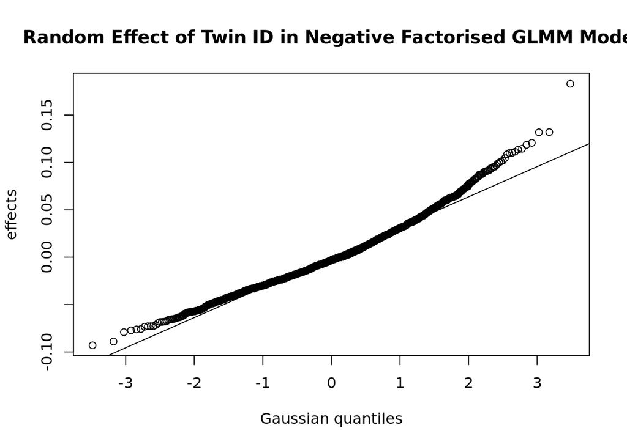

```r
neg_re <- ranef(neg_glmm_model)$cmpair[,1]
neg_qq <- qqnorm(neg_re, plot.it = FALSE)

plot(neg_qq$x, neg_qq$y,
     xlab = "Gaussian quantiles",
     ylab = "effects",
     main = "Random Effect of Twin ID in Negative Factorised GLMM Model")
abline(lm(neg_qq$y ~ neg_qq$x), col = "black")
```

### Evaluate the model predictions

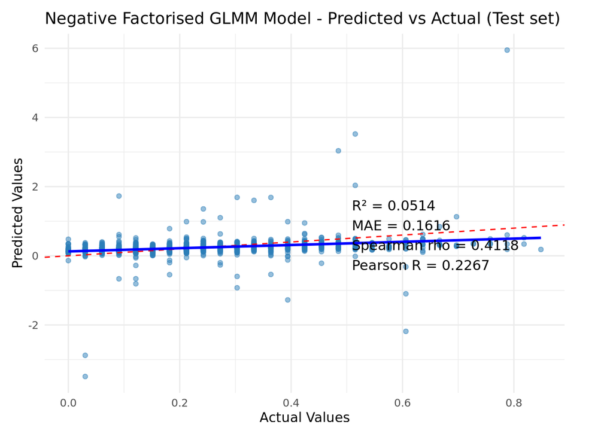

```r
neg_glmm_y_pred <- predict(neg_glmm_model, newdata = test_df, allow.new.levels = TRUE, type = "response")
neg_y_true <- test_df$SCZ18_Neg_Norm

# Create data frame
neg_glmm_df <- data.frame(
  actual = neg_y_true,
  predicted = neg_glmm_y_pred
)

# Residuals
neg_glmm_df$residuals <- neg_glmm_df$actual - neg_glmm_df$predicted

# Metrics
r2 <- cor(neg_glmm_df$actual, neg_glmm_df$predicted)^2
mae <- mean(abs(neg_glmm_df$actual - neg_glmm_df$predicted))
pearson_r <- cor(neg_glmm_df$actual, neg_glmm_df$predicted)
spearman_r <- cor(neg_glmm_df$actual, neg_glmm_df$predicted, method = "spearman")

metrics_text <- sprintf(
  "R² = %.4f\nMAE = %.4f\nSpearman rho = %.4f\nPearson R = %.4f",
  r2, mae, spearman_r, pearson_r
)

# predicted vs actual plot
p1 <- ggplot(neg_glmm_df, aes(x = actual, y = predicted)) +
  geom_point(alpha = 0.5, color = "#2C7FB8") +
  geom_abline(intercept = 0, slope = 1, linetype = "dashed", color = "red") +
  geom_smooth(method = "lm", se = FALSE, color = "blue") +

  annotate("text",
           x = max(neg_glmm_df$actual) * 0.6,
           y = max(neg_glmm_df$predicted) * 0.1,   # move inside plot
           label = metrics_text,
           hjust = 0,
           size = 4) +

  coord_cartesian(clip = "off") +  # prevents clipping

  labs(
    title = "Negative Factorised GLMM Model - Predicted vs Actual (Test set)",
    x = "Actual Values",
    y = "Predicted Values"
  ) +
  theme_minimal() +
  theme(plot.margin = margin(10, 40, 10, 10))  # extra space

p1
```

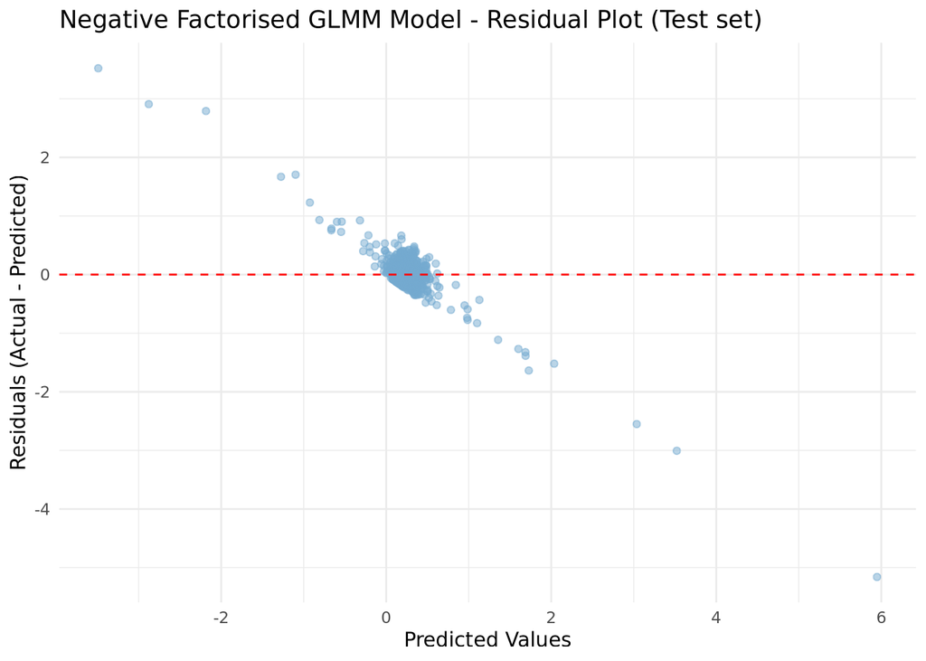

```r
# residual plot
p2 <- ggplot(neg_glmm_df, aes(x = predicted, y = residuals)) +
  geom_point(alpha = 0.5, color = "#74A9CF") +
  geom_hline(yintercept = 0, linetype = "dashed", color = "red") +

  labs(
    title = "Negative Factorised GLMM Model - Residual Plot (Test set)",
    x = "Predicted Values",
    y = "Residuals (Actual - Predicted)"
  ) +
  theme_minimal()

p2
```